# Predicting Monthly Sales for a Superstore

- Anthony Blakley, 04/21/2024
- **Goal** : The goal of this project is to build a regression model to predict monthly sales from a superstore. I will use [Nearest Neighbors Regression](https://scikit-learn.org/stable/modules/generated/sklearn.neighbors.KNeighborsRegressor.html) to make my predictions. To evaluate the performance of my model, I use the evaluation: metric [R-squared score](https://scikit-learn.org/stable/modules/generated/sklearn.metrics.r2_score.html).

## Data Collection

- Obtain the "Superstore Sales Dataset" from [Kaggle](https://www.kaggle.com/code/motaza/predicting-future-sales-with-different-models) and name it `sales.csv`.
  - This is a retail dataset of a global superstore for 4 years.
- Read the dataset into a dataframe

```python
# load the dataset
import pandas as pd
df = pd.read_csv('sales.csv')
```

## Data Exploration and Preprocessing

- Explore the Structure of the Dataset
- Handle Missing Values (If found)
- Transform data to work with pandas
  - convert `order date` to pandas `datatime` type
  - add `month` class to the data frame

#### View dataset structure

```python
# check the column names and data types
print(f'Column names and data types: {df.info()}')
```

```
<class 'pandas.core.frame.DataFrame'>
RangeIndex: 9800 entries, 0 to 9799
Data columns (total 18 columns):
 #   Column         Non-Null Count  Dtype
---  ------         --------------  -----
 0   Row ID         9800 non-null   int64
 1   Order ID       9800 non-null   object
 2   Order Date     9800 non-null   object
 3   Ship Date      9800 non-null   object
 4   Ship Mode      9800 non-null   object
 5   Customer ID    9800 non-null   object
 6   Customer Name  9800 non-null   object
 7   Segment        9800 non-null   object
 8   Country        9800 non-null   object
 9   City           9800 non-null   object
 10  State          9800 non-null   object
 11  Postal Code    9789 non-null   float64
 12  Region         9800 non-null   object
 13  Product ID     9800 non-null   object
 14  Category       9800 non-null   object
 15  Sub-Category   9800 non-null   object
 16  Product Name   9800 non-null   object
 17  Sales          9800 non-null   float64
dtypes: float64(2), int64(1), object(15)
memory usage: 1.3+ MB
Column names and data types: None
```

```python
df.head(1)
```

|  | Row ID | Order ID | Order Date | Ship Date | Ship Mode | Customer ID | Customer Name | Segment | Country | City | State | Postal Code | Region | Product ID | Category | Sub-Category | Product Name | Sales |
| --- | --- | --- | --- | --- | --- | --- | --- | --- | --- | --- | --- | --- | --- | --- | --- | --- | --- | --- |
| 0 | 1 | CA-2017-152156 | 08/11/2017 | 11/11/2017 | Second Class | CG-12520 | Claire Gute | Consumer | United States | Henderson | Kentucky | 42420.0 | South | FUR-BO-10001798 | Furniture | Bookcases | Bush Somerset Collection Bookcase | 261.96 |

#### Check & handle missing values and remove unnecessary columns

- Drop the column as we don't need it for our analysis
- Remove columns not needed in our algorithm

```python
# check for missing values
print("\nMissing values:")
print(df.isnull().sum())
```

```
Missing values:
Row ID            0
Order ID          0
Order Date        0
Ship Date         0
Ship Mode         0
Customer ID       0
Customer Name     0
Segment           0
Country           0
City              0
State             0
Postal Code      11
Region            0
Product ID        0
Category          0
Sub-Category      0
Product Name      0
Sales             0
dtype: int64
```

```python
# handle missing values in 'Postal Code'
df.dropna(subset=['Postal Code'], inplace=True)
```

```python
df.head(1)
```

|  | Row ID | Order ID | Order Date | Ship Date | Ship Mode | Customer ID | Customer Name | Segment | Country | City | State | Postal Code | Region | Product ID | Category | Sub-Category | Product Name | Sales |
| --- | --- | --- | --- | --- | --- | --- | --- | --- | --- | --- | --- | --- | --- | --- | --- | --- | --- | --- |
| 0 | 1 | CA-2017-152156 | 08/11/2017 | 11/11/2017 | Second Class | CG-12520 | Claire Gute | Consumer | United States | Henderson | Kentucky | 42420.0 | South | FUR-BO-10001798 | Furniture | Bookcases | Bush Somerset Collection Bookcase | 261.96 |

```python
# define predictors
# predictors = ['Order Date', 'Ship Mode', 'Region', 'Category', 'Sub-Category']
predictors = ['Order Date']

# drop those that aren't predictors or the target
dropping = [col for col in df.columns if col not in predictors and col != 'Sales']
df.drop(columns = dropping, inplace = True)
```

#### Explore the distribution of numerical variables

- Display the count of unique values for each predictor variable

```python
for predictor in predictors:
    unique_values = len(df[predictor].unique())
    print(f'There are {unique_values}\t different {predictor}')
```

```
There are 1229	 different Order Date
```

#### Dataset Preprocessing

- Transform Order Date predictor
- Create monthly sales: (feature engineering)
- Plot monthly sales trend

```python
# tranform date to pandas datetime
df['Order Date'] = pd.to_datetime(df['Order Date'], format = '%d/%m/%Y')

# add month feature
df['month'] = pd.to_datetime(df['Order Date']).dt.to_period('M')
```

```python
import seaborn as sns
import matplotlib.pyplot as plt

# aggregate sales data based on both year and month.
month_year_sales = df.groupby([df['Order Date'].dt.year.rename('Year'), df['Order Date'].dt.month.rename('Month')]).agg({'Sales': 'sum'}).reset_index()
month_year_sales = pd.DataFrame(month_year_sales)
```

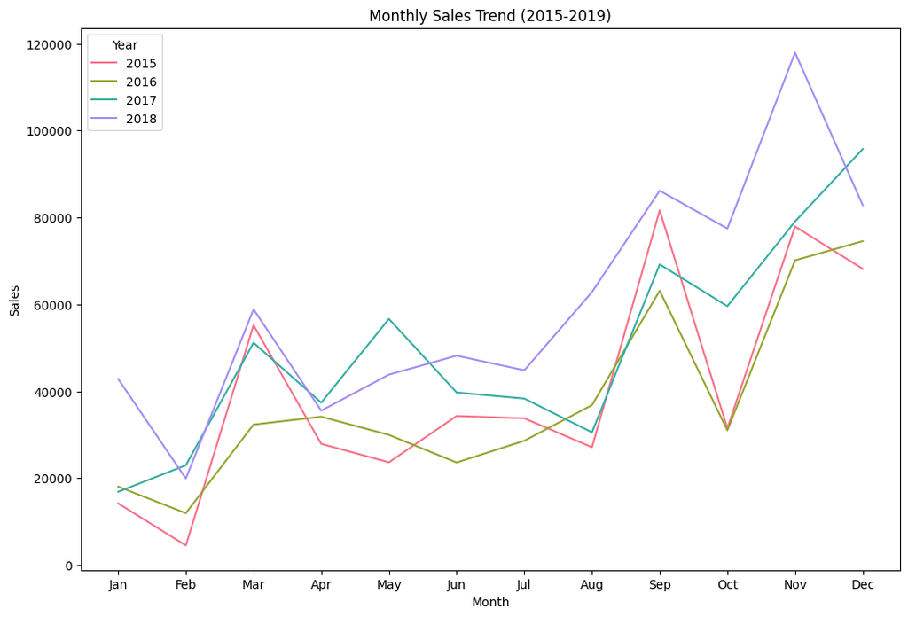

```python
# plot monthly sales trend for each year
_colors = sns.color_palette("husl", n_colors = len(month_year_sales['Year'].unique()))

# Plot monthly sales trend for each year
plt.figure(figsize=(12, 8))
sns.lineplot(x='Month', y='Sales', hue='Year', data=month_year_sales, palette=_colors)
plt.title('Monthly Sales Trend (2015-2019)')
plt.xlabel('Month')
plt.ylabel('Sales')
plt.xticks(range(1, 13), ['Jan', 'Feb', 'Mar', 'Apr', 'May', 'Jun', 'Jul', 'Aug', 'Sep', 'Oct', 'Nov', 'Dec'])
plt.legend(title='Year')
plt.show()
```

```python
# view first 10 month year sales
month_year_sales.head()
```

|  | Year | Month | Sales |
| --- | --- | --- | --- |
| 0 | 2015 | 1 | 14205.707 |
| 1 | 2015 | 2 | 4519.892 |
| 2 | 2015 | 3 | 55205.797 |
| 3 | 2015 | 4 | 27906.855 |
| 4 | 2015 | 5 | 23644.303 |

## Machine Learning Algorithm Implementation

`K-Nearest Neighbors Regression`

- Feature Selection and Data Preparation
- Create and Train the model
- Evaluate the performance of the model
- Hyperparemter tuning review
- Model Performance Comparison

#### Feature Selection and Data Preparation

```python
from sklearn.preprocessing import OneHotEncoder

# aggregates the sales data solely on a monthly basis
monthly_sales = df.groupby('month')['Sales'].sum().reset_index()

'''
match rows between the two dataframes where the values in the 'month' column are the same
maintains the 'Sales' column name and makes a new column, 'Sales_monthly'
representing the `monthly_sales_original` column
'''
df_merged = pd.merge(df, monthly_sales, on = 'month', suffixes = ('', '_monthly'))

# select predictor variables
variable_predictors = df_merged[predictors]

# select target variable
variable_target = df_merged['Sales_monthly']
```

```python
# see new column
df_merged.head(1)
```

|  | Order Date | Sales | month | Sales_monthly |
| --- | --- | --- | --- | --- |
| 0 | 2017-11-08 | 261.96 | 2017-11 | 79066.4958 |

```python
from sklearn.model_selection import train_test_split

# Split the data into training and temporary sets (80% for training + temporary)
x_train, x_temp, y_train, y_temp = train_test_split(
    variable_predictors,
    variable_target,
    test_size    = 0.2,  # 80% for training, 20% for temporary
    random_state = 0
)

# Split the temporary data into validation and testing sets (50% each)
x_validation, x_test, y_validation, y_test = train_test_split(
    x_temp,
    y_temp,
    test_size    = 0.5,  # 50% for validation, 50% for testing
    random_state = 0
)

# check the shapes of the training and testing sets
print("Shape of X_train:", x_train.shape)
print("Shape of y_train:", y_train.shape)
print("Shape of X_validation:", x_validation.shape)
print("Shape of y_validation:", y_validation.shape)
print("Shape of X_test:", x_test.shape)
print("Shape of y_test:", y_test.shape)
```

```
Shape of X_train: (7831, 1)
Shape of y_train: (7831,)
Shape of X_validation: (979, 1)
Shape of y_validation: (979,)
Shape of X_test: (979, 1)
Shape of y_test: (979,)
```

```python
from sklearn.preprocessing import OneHotEncoder

'''
In one-hot encoding, each category is represented by a binary vector where only one bit is
"hot" (set to 1), and all other bits are "cold" (set to 0). So, for the color "blue," which
is the third category in our example, the binary vector would be [0, 0, 1].
'''

# One-hot encode categorical predictors (encodes any categorical predictors)
encoder = OneHotEncoder(handle_unknown = 'ignore')
x_train = encoder.fit_transform(x_train)
```

| Original Color | Encoded Red | Encoded Green | Encoded Blue |
| --- | --- | --- | --- |
| Red | 1 | 0 | 0 |
| Green | 0 | 1 | 0 |
| Blue | 0 | 0 | 1 |

#### Model Development and Train

```python
from sklearn.neighbors import KNeighborsRegressor

# use 3 neighbors to predict the value, consider neighbors closer to the target more important (distance)
# using weights="uniform" (default) weighs all points equally
model = KNeighborsRegressor(n_neighbors = 3, weights = "distance")

# compute and store the nearest neighbors of each training sample
model.fit(x_train, y_train)
```

```
KNeighborsRegressor(n_neighbors=3, weights='distance')
```

#### Model Evaluation

- predictions on the training set
- predictions on the test set
- predictions on the validation set
- calculate R2 metric

```python
# training set
y_train_pred = model.predict(x_train)

# test set
x_test_encoded = encoder.transform(x_test) # [ transform new data using same encoding scheme ]
y_test_pred = model.predict(x_test_encoded)

# validation set
x_validation_encoded = encoder.transform(x_validation)
y_validation_pred = model.predict(x_validation_encoded)
```

```python
from sklearn.metrics import r2_score

'''
An R-Squared value shows how well the model predicts the outcome of the dependent variable.
R-Squared values range from 0 to 1.

An R-Squared value of 0 means that the model explains or predicts 0% of the relationship
between the dependent and independent variables.
A value of 1 indicates that the model predicts 100% of the relationship.
'''

train_r2      = r2_score(y_train, y_train_pred)
test_r2       = r2_score(y_test, y_test_pred)
validation_r2 = r2_score(y_validation, y_validation_pred)

print("Training    R-squared: ", train_r2)
print("Testing     R-squared: ", test_r2)
print("Validation  R-squared: ", validation_r2)
```

```
Training    R-squared:  1.0
Testing     R-squared:  0.9873650049153772
Validation  R-squared:  0.9831708628568755
```

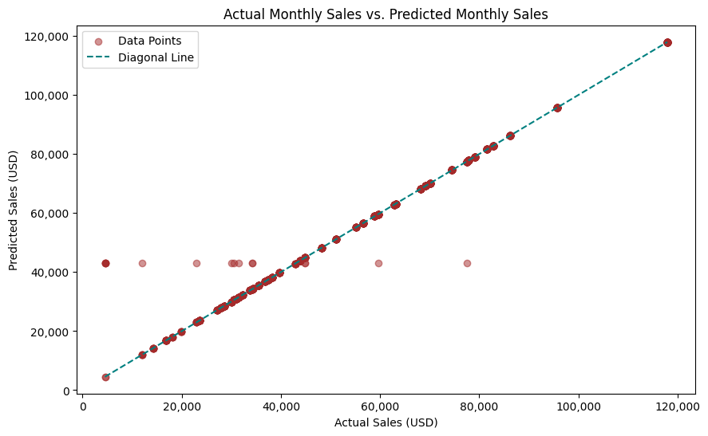

```python
import numpy as np
import matplotlib.pyplot as plt
import matplotlib.ticker as ticker

# plot the scatter plot
plt.figure(figsize=(10, 6))
plt.scatter(y_validation, y_validation_pred, color='brown', alpha=0.5, label='Data Points')

# plot the diagonal line
plt.plot([min(y_validation), max(y_validation)], [min(y_validation), max(y_validation)], color='teal', linestyle='--', label='Diagonal Line')

plt.xlabel('Actual Sales (USD)')
plt.ylabel('Predicted Sales (USD)')
plt.title('Actual Monthly Sales vs. Predicted Monthly Sales')
plt.legend()

formatter = ticker.FuncFormatter(lambda x, _: '{:,.0f}'.format(x))
plt.gca().xaxis.set_major_formatter(formatter)
plt.gca().yaxis.set_major_formatter(formatter)
plt.show()
```

### Hyperparameter tuning analysis

- illustrations for the model's performance gains
- Model optimization progression
  - splitting data using 3 sets instead of 2
    - splitting using 80-10-10 instead of 80-20 & 70-30 (using two sets)
  - using a variation of predictors instead of the most influential one
  - using 3 neighbors vs 5 neighbors
  - distance weight instead of uniform

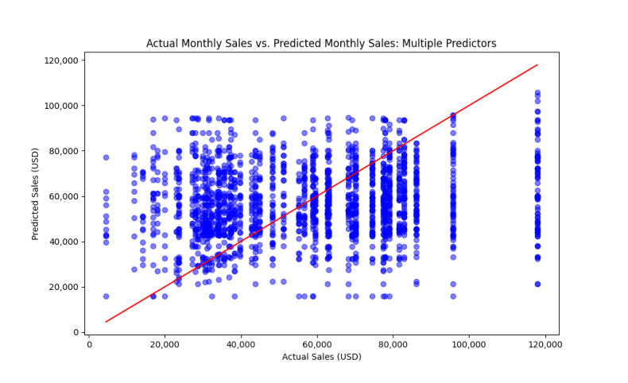

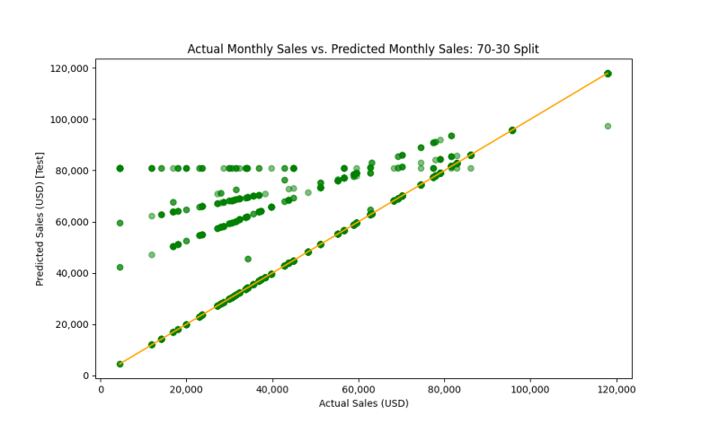

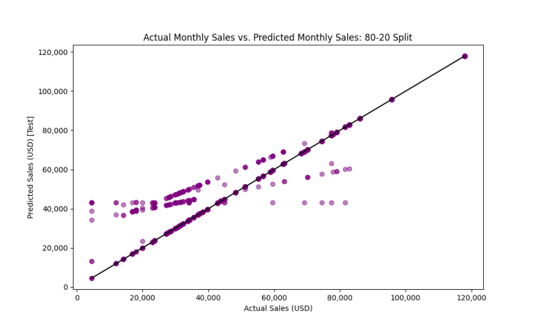

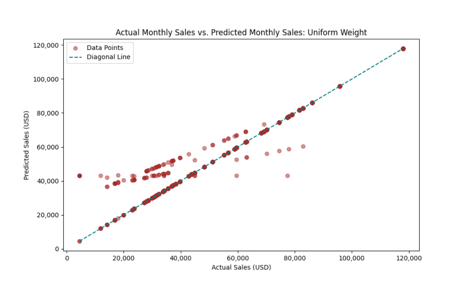

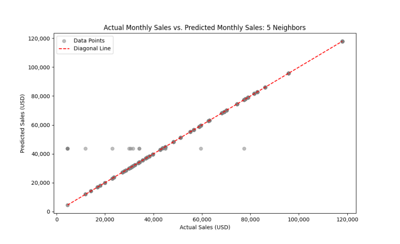

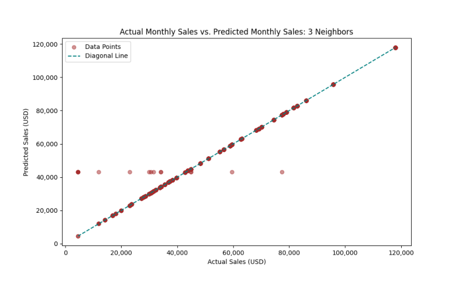

```python
import matplotlib.pyplot as plt
import os

# list of image files
image_files = [
    'sales_plot3.png',  # Plot Predictions Model using multiple predictors
    'sales_plot2.png',  # Plot Predictions Model using training-testing sets with (70-30) split
    'sales_plot1.png',  # Plot Predictions Model using training-testing sets with (80-20) split
    'sales_plot6.png',  # Plot Predictions Model using uniform weight
    'sales_plot5.png',  # Plot Predictions Model using 5 neighbors
    'sales_plot7.png',  # Plot Predictions Model using 3 neighbors
]

# loop through each image file and plot it
for image_file in image_files:
    img = plt.imread(image_file)
    plt.figure(figsize=(10, 6))
    plt.imshow(img)
    plt.axis('off')
    plt.show()
```

### Model Performance Comparison

- Comparison between my model that uses `KNeighborsRegressor` on the training and test sets and the baseline provided by [Motaz's model using `LinearRegression`](https://www.kaggle.com/code/motaza/predicting-future-sales-with-different-models?scriptVersionId=172067066)

| Algorithm | Training R-squared | Testing R-squared |
| --- | --- | --- |
| KNeighborsRegressor | 1.0 | 0.9874 |
| LinearRegression | 0.9105 | 0.7355 |